# Homework #3: Penalized Regression

SOLUTIONS

Due: Wed Sept 21 | 11:45am

**DS 6030 | Fall 2022 | University of Virginia**

These solutions are only for the private use of the students of DS 6030 Fall 2022. Sharing of the solutions, posting on the internet, selling to a company, or possession by anyone else at the University of Virginia constitutes a violation of the honor policy.

# Required R packages and Directories

```r
data.dir = 'https://mdporter.github.io/DS6030/data/' # data directory
library(mlbench)
library(glmnet)
library(R6030)     # functions for DS-6030
library(tidyverse) # functions for data manipulation
```

# Problem 1: Optimal Tuning Parameters

In cross-validation, we discussed choosing the tuning parameter values that minimized the cross-validation error. Another approach, called the “one-standard error” rule [ISL pg 214, ESL pg 61], uses the values corresponding to the least complex model whose cv error is within one standard error of the best model. The goal of this assignment is to compare these two rules.

Use simulated data from `mlbench.friedman1(n, sd=2)` in the `mlbench` R package to fit *lasso models*. The tuning parameter $\lambda$ (corresponding to the penalty on the coefficient magnitude) is the one we will focus one. Generate training data, use k-fold cross-validation to get $\lambda_{\rm min}$ and $\lambda_{\rm 1SE}$, generate test data, make predictions for the test data, and compare performance of the two rules under a squared error loss using a hypothesis test.

Choose reasonable values for:

- Number of cv folds ($K$)
  - Note: you are free to use repeated CV, repeated hold-outs, or bootstrapping instead of plain cross-validation; just be sure to describe what do did so it will be easier to follow.
- Number of training and test observations
- Number of simulations
- If everyone uses different values, we will be able to see how the results change over the different settings.
- Don’t forget to make your results reproducible (e.g., set seed)

This pseudo code will get you started:

```yaml
library(mlbench)
library(glmnet)

#-- Settings
n.train =        # number of training obs
n.test =         # number of test obs
K =              # number of CV folds
alpha =          # glmnet tuning alpha (1 = lasso, 0 = ridge)
M =              # number of simulations

#-- Data Generating Function
getData <- function(n) mlbench.friedman1(n, sd=2) # data generating function

#-- Simulations
# Set Seed Here

for(m in 1:M) {

# 1. Generate Training Data
# 2. Build Training Models using cross-validation, e.g., cv.glmnet()
# 3. get lambda that minimizes cv error and 1 SE rule
# 4. Generate Test Data
# 5. Predict y values for test data (for each model: min, 1SE)
# 6. Evaluate predictions

}

#-- Compare
# compare performance of the approaches / Statistical Test
```

## a. Code for the simulation and performance results

When there is sufficient data a more complex model may give very similar performance to the optimal (i.e., the variance is reduced by the large sample size) or even better (e.g., if the smaller training set under cross-validation has an effect). Thus, in addition to using the $\lambda$ values corresponding the to the min CV and one-standard-error, I also show the performance using no penalty ($\lambda=0$).

```r
library(mlbench)
library(glmnet)

#-- Settings
n.train = 1000      # number of training obs
n.test = 10000      # number of test obs
K = 10              # number of CV folds
alpha = 1           # glmnet tuning alpha (1 = lasso, 0 = ridge)
M = 200             # number of simulations

#-- Data Generating Function
getData <- function(n) mlbench.friedman1(n, sd=2) # data generating function

#-- Simulations
set.seed(2019)
MSE = matrix(NA, M, 3); colnames(MSE)=c("0", "cv.min", "1SE")

for(m in 1:M){

  #- Generate training data
  d.train = getData(n.train)

  #- Build training model using cross-validation
  cv.fit = cv.glmnet(d.train$x, d.train$y, nfolds=K, alpha=alpha)

  #- Set Lambda values to evaluate
  lambda = c(0, cv.fit$lambda.min, cv.fit$lambda.1se)

  #- Generate test data
  d.test = getData(n.test)

  #- Predict y values for test data (for each model)
  #  note: this uses predict.cv.glmnet(); model fit with all data.
  yhat = predict(cv.fit, d.test$x, s=lambda, type="response")

  #- evaluate predictions (MSE criterion)
  mse = apply(yhat, 2, function(f) mean((d.test$y-f)^2 ))
  MSE[m,] = mse
}
```

```r
colMeans(MSE)
```

```
#>      0 cv.min    1SE
#>  9.992  9.984 10.406
```

```r
#- Results
mu = colMeans(MSE)                               # means
MOE = pt(.975, df=M-1)*apply(MSE, 2, sd)/sqrt(M) # margin of error
```

The MSE is **9.984** for $\lambda_{\rm min}$, **10.406** for $\lambda_{\rm 1SE}$, and **9.992** for $\lambda=0$.

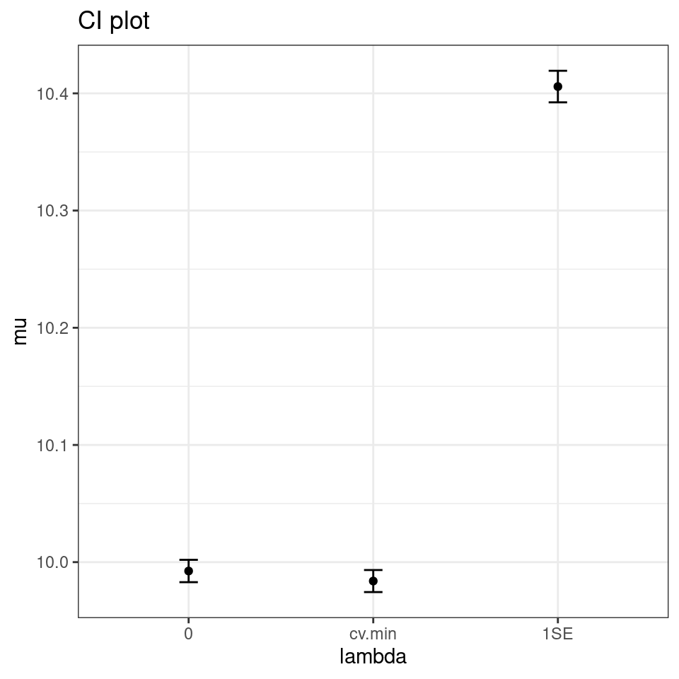

```r
#- Mean with CI
tibble(lambda = names(mu), mu, MOE) %>%
  ggplot(aes(lambda, mu)) +
  geom_point() +
  geom_errorbar(aes(ymin=mu-MOE, ymax=mu+MOE), width = 0.1) +
  scale_x_discrete(limits = c("0", "cv.min", "1SE")) +
  labs(title="CI plot")
```

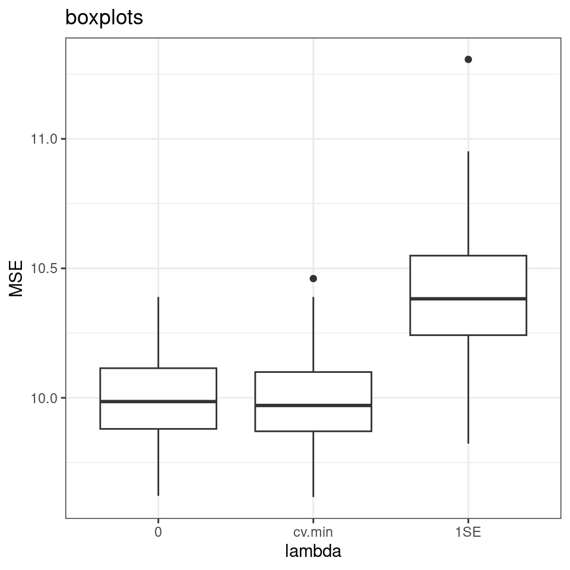

```r
#- Boxplots
MSE %>% as_tibble() %>%
  pivot_longer(everything(), names_to='lambda', values_to="MSE") %>%
  ggplot(aes(lambda, MSE)) + geom_boxplot() +
  scale_x_discrete(limits = c("0", "cv.min", "1SE")) +
  labs(title="boxplots")
```

```r
# boxplot(MSE, las=1, xlab='', ylab='MSE', main="boxplots")
```

It looks like the minimum rule (lambda that minimizes the cross-validation error) is the best option for this data generating function. In this case, using a more complex model does not do much worse. Your results may differ depending on the what you used for `n.train` and `K`.

## b. Description and results of a hypothesis test comparing $\lambda_{\rm min}$ and $\lambda_{\rm 1SE}$.

We can formally test if the minimum rule is better than the 1se rule with a *paired* test. Here are two common options: paired t-test (parametric) and Monte Carlo permutation test (non-parametric).

#### Paired t-test

We can formally test if the minimum rule is better than the 1se rule with a *paired* t-test.

```r
#- Paired t-test
t.test(MSE[, '1SE'], MSE[, 'cv.min'], paired=TRUE)
```

```
#>
#>  Paired t-test
#>
#> data:  MSE[, "1SE"] and MSE[, "cv.min"]
#> t = 34, df = 199, p-value <2e-16
#> alternative hypothesis: true mean difference is not equal to 0
#> 95 percent confidence interval:
#>  0.3975 0.4464
#> sample estimates:
#> mean difference
#>          0.4219
```

We have statistical significance.

#### Monte Carlo permutation test

A match pairs resampling procedure could also be used instead of CLT-based paired t-test.

First find the the observed mean difference (test statistic):

```r
#- Get observed differences
d = MSE[, '1SE'] - MSE[, 'cv.min']
mean(d)
```

```
#> [1] 0.4219
```

Now we need to ask if 0.42 is an unexpected deviation from the null. This is easy to evaluate. Under the null (of no difference) the sign of the differences is $U(\{-1, +1\})$. So to draw a sample under the null, we only need to sample the sign.

```r
#- Null Hypothesis is no difference. Resampling under null implies that either
#  could have produced the score
M = 2000
dnull = numeric(M)
set.seed(2021)
for(i in 1:M){
  sign = sample(c(-1, 1), length(d), replace=TRUE)
  dnull[i] = mean(sign*d)
}
```

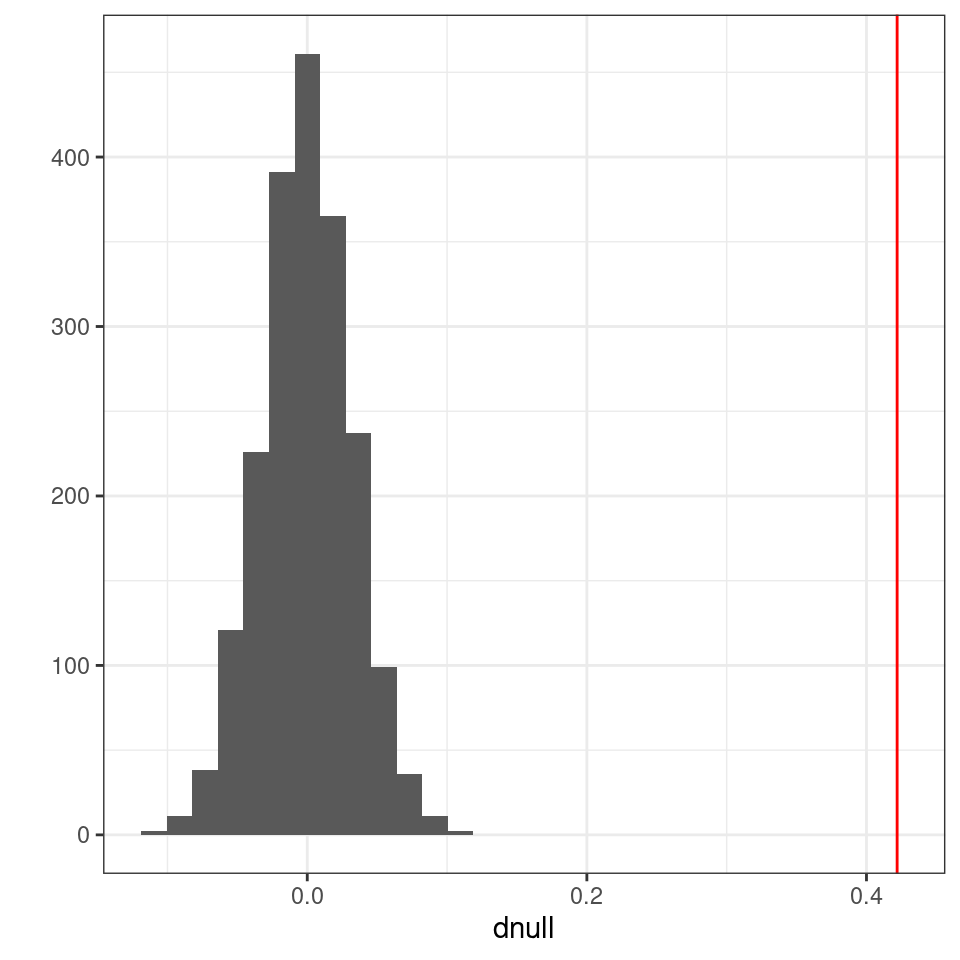

```r
qplot(dnull, bins=30) + geom_vline(xintercept=mean(d), color="red")
```

Obviously, we have significance!

But to carry ahead with the official numbers, the one-sided Monte Carlo estimated p-value is
$$\frac{1+\text{# resamples with } \bar{d}_{\rm null}
\geq \bar{d}}{1+\text{# of resamples}}$$
where the $(1 + )$ includes the original sample. In our case, we get p-value = 5e-04 (which would even be less if we used more Monte Carlo samples),

# Problem 2 Prediction Contest: Real Estate Pricing

This problem uses the [realestate-train](https://mdporter.github.io/DS6030/data//realestate-train.csv) and [realestate-test](https://mdporter.github.io/DS6030/data//realestate-test.csv) (click on links for data).

The goal of this contest is to predict sale price (in thousands) (`price` column) using an *elastic net* model. Evaluation of the test data will be based on the root mean squared error ${\rm RMSE}= \sqrt{\frac{1}{m}\sum_i (y_i - \hat{y}_i)^2}$ for the $m$ test set observations.

## a. Load the data and create necessary data structures for running *elastic net*.

- You are free to use any data transformation or feature engineering
- Note: there are some categorical predictors so at the least you will have to convert those to something numeric (e.g., one-hot or dummy coding).

```r
#-- load data
library(readr)
train = read_csv(file.path(data.dir, 'realestate-train.csv'))
test = read_csv(file.path(data.dir, 'realestate-test.csv'))
```

The function `skim()` in the `skimr` package is an improved version of `base::summary()` that provides a basic description of the data.

```r
library(skimr)
skim(train)
```

Data summary

| Name | train |
| --- | --- |
| Number of rows | 1160 |
| Number of columns | 13 |
| _______________________ |  |
| Column type frequency: |  |
| character | 3 |
| numeric | 10 |
| ________________________ |  |
| Group variables | None |

**Variable type: character**

| skim_variable | n_missing | complete_rate | min | max | empty | n_unique | whitespace |
| --- | --- | --- | --- | --- | --- | --- | --- |
| CentralAir | 0 | 1 | 1 | 1 | 0 | 2 | 0 |
| BldgType | 0 | 1 | 4 | 6 | 0 | 5 | 0 |
| HouseStyle | 0 | 1 | 4 | 6 | 0 | 8 | 0 |

**Variable type: numeric**

| skim_variable | n_missing | complete_rate | mean | sd | p0 | p25 | p50 | p75 | p100 | hist |
| --- | --- | --- | --- | --- | --- | --- | --- | --- | --- | --- |
| price | 0 | 1 | 182.28 | 80.68 | 40 | 130.4 | 163.9 | 215 | 755 | ▇▅▁▁▁ |
| PoolArea | 0 | 1 | 3.06 | 42.82 | 0 | 0.0 | 0.0 | 0 | 738 | ▇▁▁▁▁ |
| GarageCars | 0 | 1 | 1.78 | 0.75 | 0 | 1.0 | 2.0 | 2 | 4 | ▁▃▇▂▁ |
| Fireplaces | 0 | 1 | 0.60 | 0.64 | 0 | 0.0 | 1.0 | 1 | 3 | ▇▇▁▁▁ |
| TotRmsAbvGrd | 0 | 1 | 6.51 | 1.59 | 3 | 5.0 | 6.0 | 7 | 14 | ▅▇▃▁▁ |
| Baths | 0 | 1 | 1.95 | 0.79 | 0 | 1.0 | 2.0 | 3 | 4 | ▁▆▇▅▁ |
| SqFeet | 0 | 1 | 1509.45 | 508.24 | 438 | 1127.5 | 1466.0 | 1777 | 4676 | ▆▇▂▁▁ |
| Age | 0 | 1 | 35.73 | 29.94 | 0 | 7.0 | 34.0 | 54 | 135 | ▇▆▂▂▁ |
| LotSize | 0 | 1 | 10502.76 | 10663.34 | 1300 | 7552.2 | 9423.0 | 11516 | 215245 | ▇▁▁▁▁ |
| condition | 0 | 1 | 5.57 | 1.11 | 1 | 5.0 | 5.0 | 6 | 9 | ▁▁▇▅▁ |

```r
skim(test)
```

Data summary

| Name | test |
| --- | --- |
| Number of rows | 300 |
| Number of columns | 12 |
| _______________________ |  |
| Column type frequency: |  |
| character | 3 |
| numeric | 9 |
| ________________________ |  |
| Group variables | None |

**Variable type: character**

| skim_variable | n_missing | complete_rate | min | max | empty | n_unique | whitespace |
| --- | --- | --- | --- | --- | --- | --- | --- |
| CentralAir | 0 | 1 | 1 | 1 | 0 | 2 | 0 |
| BldgType | 0 | 1 | 4 | 6 | 0 | 5 | 0 |
| HouseStyle | 0 | 1 | 4 | 6 | 0 | 8 | 0 |

**Variable type: numeric**

| skim_variable | n_missing | complete_rate | mean | sd | p0 | p25 | p50 | p75 | p100 | hist |
| --- | --- | --- | --- | --- | --- | --- | --- | --- | --- | --- |
| PoolArea | 0 | 1 | 1.60 | 27.71 | 0 | 0 | 0 | 0 | 480 | ▇▁▁▁▁ |
| GarageCars | 0 | 1 | 1.73 | 0.75 | 0 | 1 | 2 | 2 | 4 | ▁▃▇▂▁ |
| Fireplaces | 0 | 1 | 0.65 | 0.65 | 0 | 0 | 1 | 1 | 3 | ▇▇▁▂▁ |
| TotRmsAbvGrd | 0 | 1 | 6.56 | 1.76 | 2 | 5 | 6 | 7 | 12 | ▂▇▆▂▁ |
| Baths | 0 | 1 | 1.93 | 0.80 | 0 | 1 | 2 | 3 | 4 | ▁▇▇▅▁ |
| SqFeet | 0 | 1 | 1538.71 | 587.76 | 334 | 1138 | 1442 | 1778 | 5642 | ▇▇▁▁▁ |
| Age | 0 | 1 | 39.71 | 31.27 | 0 | 10 | 37 | 57 | 136 | ▇▇▃▃▁ |
| LotSize | 0 | 1 | 10571.24 | 6735.95 | 1680 | 7584 | 9600 | 11704 | 63887 | ▇▁▁▁▁ |
| condition | 0 | 1 | 5.59 | 1.12 | 3 | 5 | 5 | 6 | 9 | ▁▇▃▂▁ |

Notice that we have several categorical (`character`) predictors. These need to be converted (encoded) to numeric values for use in models. There are a few ways to do this. The `model.matrix()` function will convert the categorical variables into dummy variables using the default one-less encoding. However for penalized regression, we can use the full one-hot encoding (one column for each level) so we don’t need to keep track of the reference levels. The `glmnet::makeX()` function will implement one-hot encoding. It also combines train and test data so all levels will be present in both.

```r
#-- get model matrix
library(glmnet)
X = glmnet::makeX(select(train, -price), test)
X.train = X$x
X.test = X$xtest
Y.train = train$price
```

## b. Use an *elastic net* model to predict the `price` of the test data.

- You are free to use any data transformation or feature engineering
- You are free to use any tuning parameters
- Report the $\alpha$ and $\lambda$ parameters you used to make your final predictions.
- Describe how you choose those tuning parameters

One question that always comes up is how to pick the tuning parameter $\alpha$? Let’s examine how sensitive the performance is to $\alpha$.

One thing that we have to be careful about is the **variation due to the folds**. Here is the wrong way to compare alpha:

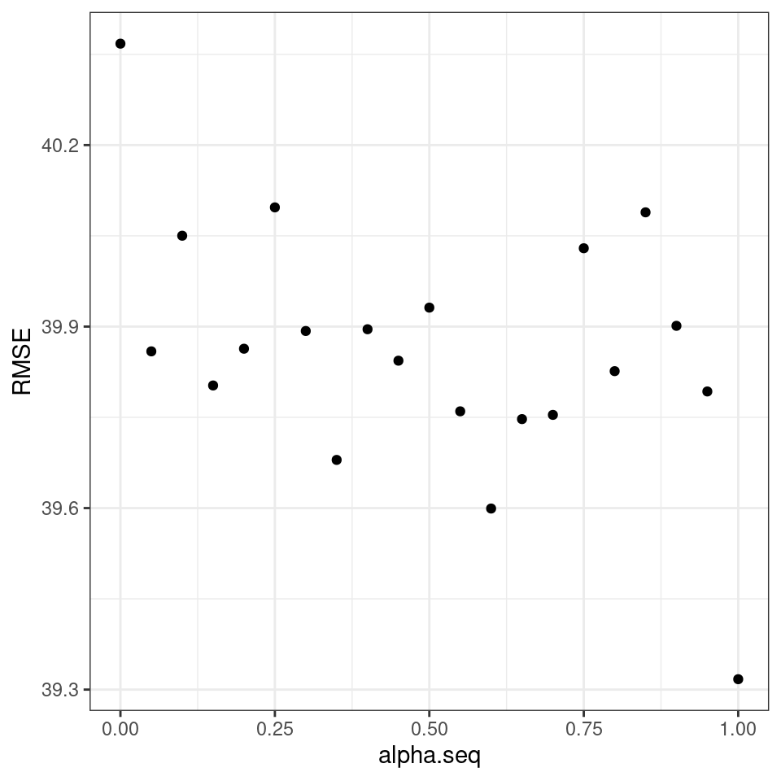

```r
library(glmnet)
library(purrr)

#-- Function that returns the minimum CV-RMSE (according to lambda.min) for a given alpha
est_rmse <- function(alpha){
  mse = cv.glmnet(X.train, Y.train, nfolds=10, alpha=alpha)$cvm %>% min()
  sqrt(mse)

}

#-- Set alpha sequence
alpha.seq = seq(0, 1, by=.05)

#-- estimate scores
set.seed(1)    # set seed because cv.glmnet() sets the CV folds
RMSE =  purrr::map_dbl(alpha.seq, \(a) est_rmse(a))

#-- Plot results
qplot(alpha.seq, RMSE)
```

You may be wondering why this is incorrect? While it’s reproducible since we set the seed before running our `est_mse()`, the function `cv.glmnet()` *uses a different fold for each $\alpha$*. The uncertainty due to the folds could be more than the uncertainty due to alpha! A better way to isolate the effect of alpha would be to use the same folds/partition for all alpha values. We use the `foldid` argument to specify the CV partition:

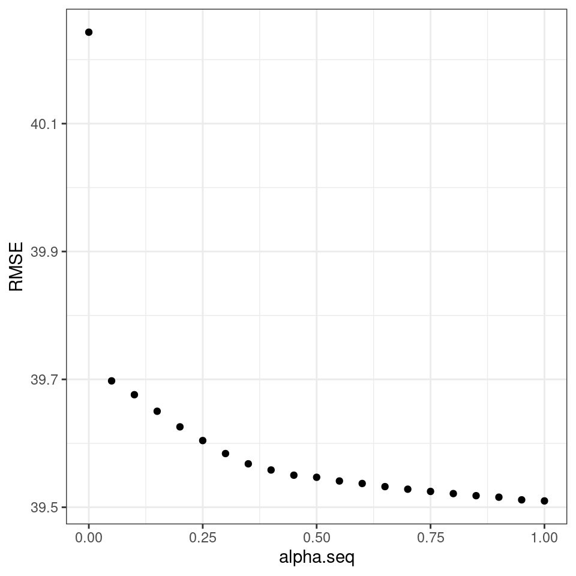

```r
library(glmnet)

#-- Set folds so consistent over all runs
set.seed(9903)   # set seed to reproducible
K = 10           # number of folds
folds = rep(1:K, length=nrow(X.train)) %>% sample() # make folds

#-- Function that returns the minimum CV-RMSE (according to lambda.min) for a given alpha and folds
est_rmse <- function(alpha, folds){
  mse = cv.glmnet(X.train, Y.train, foldid = folds, alpha=alpha)$cvm %>% min()
  sqrt(mse)
}

#-- Set alpha sequence
alpha.seq = seq(0, 1, by=.05)

#-- estimate scores
RMSE = purrr::map_dbl(alpha.seq, \(a) est_rmse(a, folds=folds))

#-- Plot results
qplot(alpha.seq, RMSE)
```

This gives a different picture. First notice the range is much lower - now the variation is only due to differences in $\alpha$. We also see a different shape with $\alpha = 1$ giving the lowest RMSE.

This should give you concern about how strong the sampling effects are. One thing we can do is used *repeated cross-validation*:

```r
set.seed(2)
RMSE2 = tibble()
for(i in 1:50){
  folds_new = sample(folds) # shuffle folds
  rmse = tibble(
    iter = i,
    alpha = alpha.seq,
    RMSE = purrr::map_dbl(alpha.seq, \(a) est_rmse(a, folds=folds_new))
  )
  RMSE2 = bind_rows(RMSE2, rmse)
}
```

This will reveal the variation due to sampling:

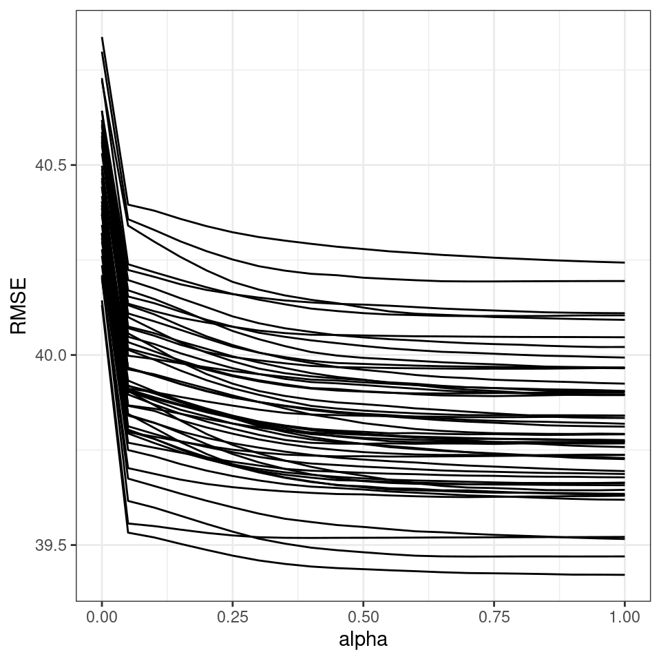

```r
RMSE2 %>%
  ggplot(aes(alpha, RMSE, group=iter)) + geom_line()
```

Quite strong for these data.

We can summarize using boxplots and means:

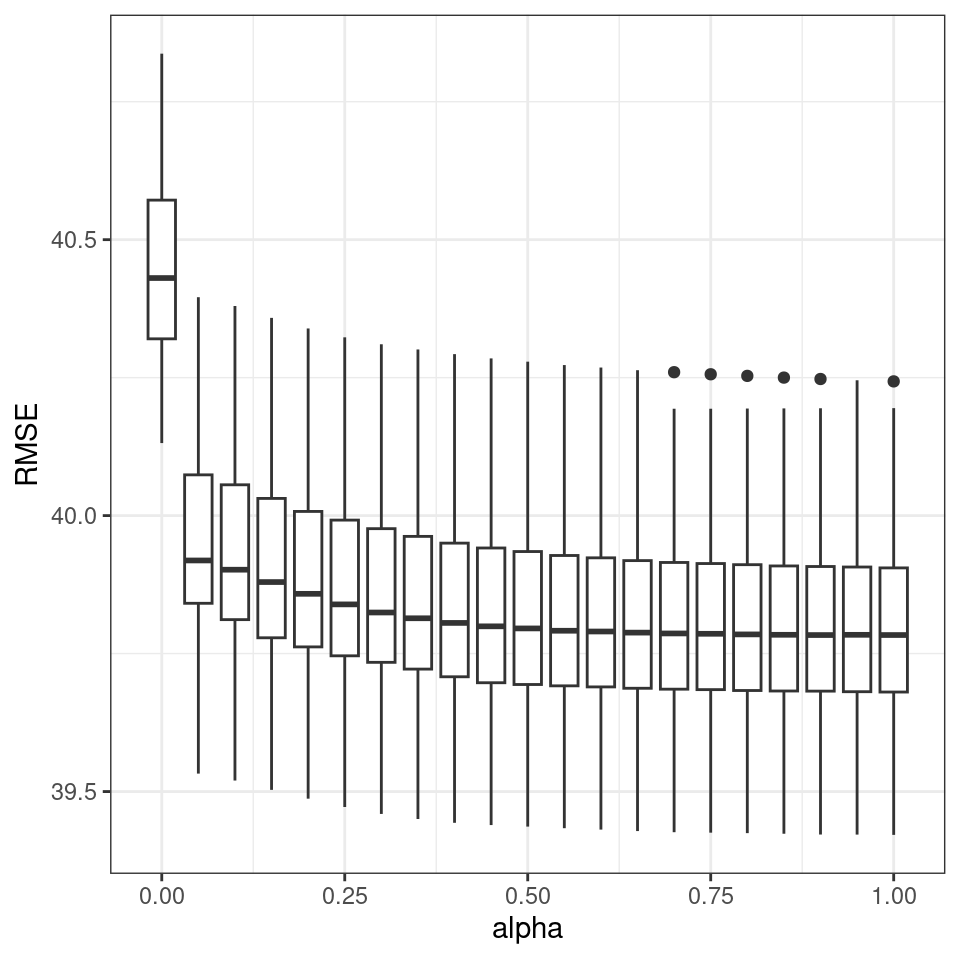

```r
#- Boxplot
RMSE2 %>%
  ggplot(aes(alpha, RMSE, group=alpha)) + geom_boxplot()
```

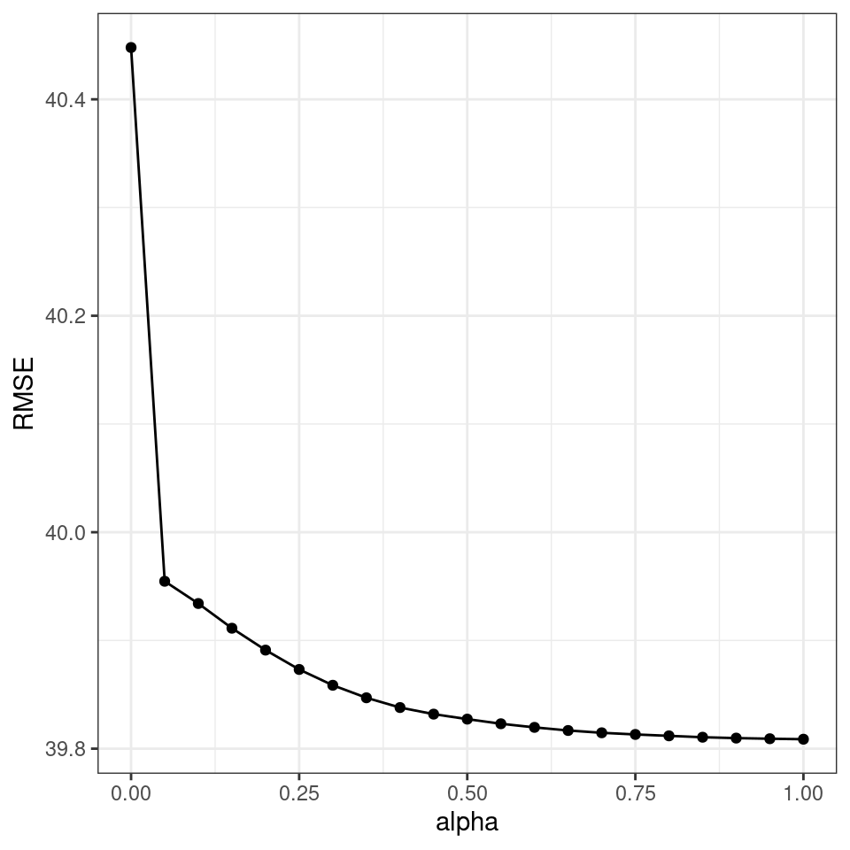

```r
#- Mean plot
RMSE.mu = RMSE2 %>%
  group_by(alpha) %>% summarize(RMSE=mean(RMSE), RMSE.median = median(RMSE))

RMSE.mu %>%
  group_by(alpha) %>% summarize(RMSE=mean(RMSE)) %>%
  ggplot(aes(alpha, RMSE)) + geom_point() + geom_line()
```

```r
#- Mean Table
RMSE.mu %>% arrange(RMSE)
```

| alpha | RMSE | RMSE.median |
| --- | --- | --- |
| 1.00 | 39.81 | 39.81 |
| 0.95 | 39.81 | 39.81 |
| 0.90 | 39.81 | 39.81 |
| 0.85 | 39.81 | 39.81 |
| 0.80 | 39.81 | 39.81 |
| 0.75 | 39.81 | 39.81 |
| 0.70 | 39.81 | 39.81 |
| 0.65 | 39.82 | 39.82 |
| 0.60 | 39.82 | 39.82 |
| 0.55 | 39.82 | 39.82 |

[output cut: 11 more lines]

```r
#- best alpha
(alpha.hat = RMSE.mu %>% slice_min(RMSE) %>% pull(alpha) )
```

```
#> [1] 1
```

Interesting pattern. Besides $\alpha=0$, most alphas give similar performance. The differences we saw in the single comparison are just due to the randomness in picking the folds. The single best alpha, using the mean RMSE, is $\alpha = 1$.

Now to choose the optimal $\lambda$ value, given we are using $\alpha = 1$.

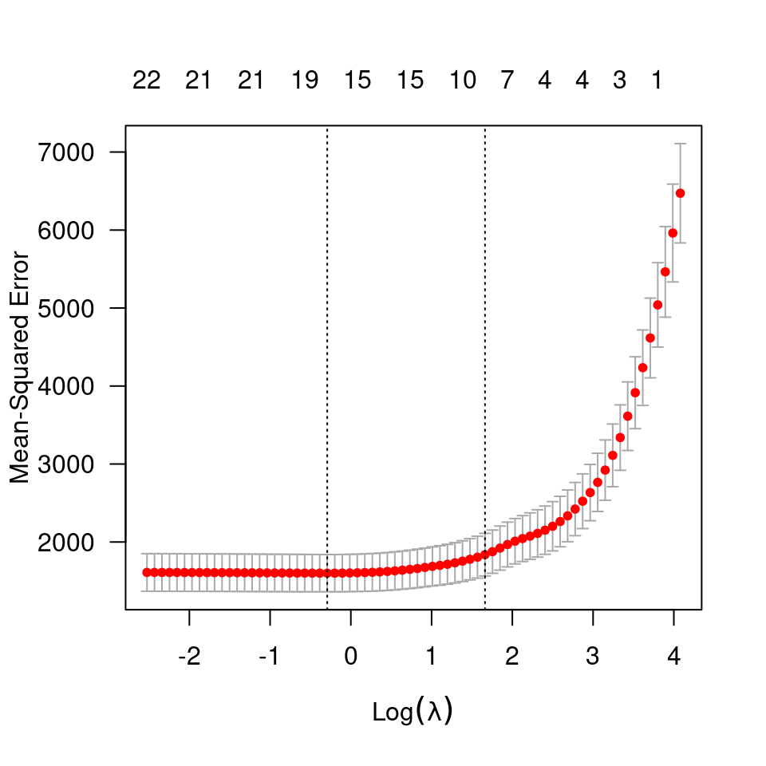

```r
set.seed(3)
K = 10                # folds for cross-validation
cv.fit = cv.glmnet(X.train, Y.train, nfolds=K, alpha=alpha.hat)
plot(cv.fit, las=1)
```

Again, we see a flat curve suggesting that a wide range of $\lambda$ values should give comparable performance, but based on the results from problem 3.1, I’ll use $\lambda_{\rm min}$ as the $\lambda$ value.

```r
(lambda.hat = cv.fit$lambda.min)
```

```
#> [1] 0.7465
```

This gives $\alpha = 1$ and $\lambda = 0.7465$ for the values to generate predictions.

## c. Submit a .csv file (ensure comma separated format) named `lastname_firstname.csv` that includes your predictions in a column named *yhat*. We will use automated evaluation, so the format must be exact.

- You will receive credit for a proper submission; the top five scores will receive 2 bonus points.

```r
#-- Fit model on full data
fit = glmnet(X.train, Y.train, alpha=alpha.hat)

#-- Make predictions at optimal lambda
yhat = predict(fit, newx=X.test, s=lambda.hat)[,1]

#-- Submit
tibble(yhat) %>% write_csv("lastname_firstname.csv")
```

## d. Report the anticipated performance of your method in terms of RMSE. We will see how close your performance assessment matches the actual value.

Notice that this final model (letting `cv.glmnet()` select the folds) gives an estimated performance of (corresponding to $\lambda_{\rm min}$).

```r
ind = which.min(cv.fit$cvm)
sqrt(cv.fit$cvm[ind])   # RMSE estimate
```

```
#> [1] 40.01
```

Because we select the best score from cross-validation, its likely that we overestimate the performance. However, since we haven’t spoken about adjustments, I’ll go with the min CV error.

However, this still ignores the uncertainty of the folds (you just can’t get away from the uncertainty!). A better point estimate could be obtained by averaging the results from the repeated cross-validation. A plot and confidence interval for good measure:

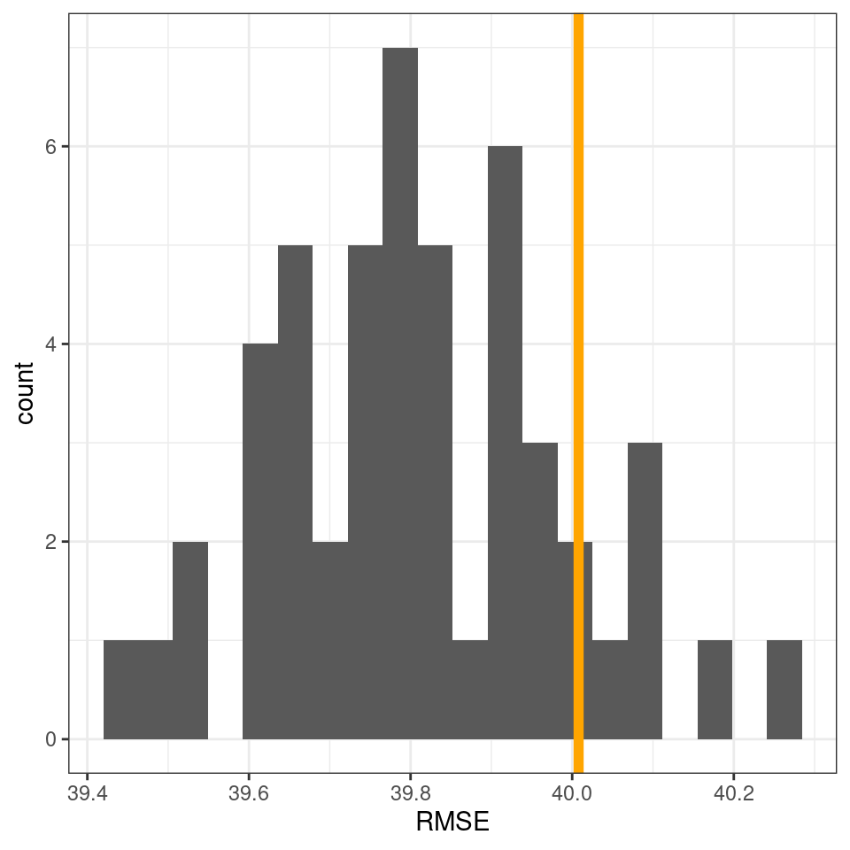

```r
#-- Repeated CV estimate of performance
perf = RMSE2 %>% filter(alpha == alpha.hat)

perf %>%
  ggplot(aes(RMSE)) + geom_histogram(bins = 20) +
  geom_vline(xintercept= sqrt(cv.fit$cvm[ind]), color="orange", linewidth=2)
```

```r
(mean(perf$RMSE))   # mean estimate
```

```
#> [1] 39.81
```

```r
(qt(.975, df=nrow(perf)-1)*sd(perf$RMSE)/sqrt(n_distinct(RMSE2$iter))) # margin of error
```

```
#> [1] 0.05145
```

Now, use the chosen tuning parameters to make predictions using the full data:

```r
#-- Fit model on full data
fit = glmnet(X.train, Y.train, alpha=alpha.hat)

#-- Make predictions at optimal lambda
yhat = predict(fit, newx=X.test, s=lambda.hat)[,1]
```

How did my solution do? Not as good as expected.

```r
data.test = read_csv("../data/realestate-test2.csv")
yardstick::rmse_vec(truth=data.test$price, yhat)
```

```
#> [1] 45.37
```

I was indeed over-confident; or - did I have an outlier in the test set?

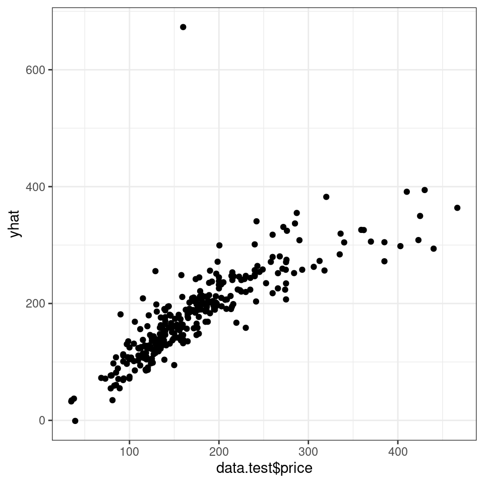

```r
qplot(data.test$price, yhat, geom="point")
```

```r
#-- RMSE after removing outlier:
tibble(truth = data.test$price, estimate = yhat) %>%
  mutate(residual.sq = (truth - estimate)^2) %>%
  filter(min_rank(-residual.sq) >1 ) %>%
  summarize(RMSE = mean(residual.sq) %>% sqrt())
```

| RMSE |
| --- |
| 34.42 |

Removing the outlier, my RMSE is much better than expected! This makes me think there are also outliers in training data. I should go back and check. Should I use a more robust loss function? Should I remove all outliers? You should be realizing by now that real data analysis is never as simple as it first appears!